# 01 · Plasticity

## Load packages

```r
pacman::p_load(here, limpa, limma, dplyr, tidyr, tibble, purrr, readr, readxl, ggplot2,
  patchwork, ggrepel, writexl)
here::i_am("08_Plasticity/01_plasticity/a_script/01_plasticity.qmd")
set.seed(2026)
```

## Read inputs

Earlier stages test BFR against HLRT one protein, set or module at a time and find no between-arm hit, so this step compares the two training responses as wholes.

```r
stage <- here("08_Plasticity", "01_plasticity")
proteins <- readRDS(here("01_Preprocess", "02_Quantification", "c_data", "proteins.rds"))
adjusted <- readRDS(here("01_Preprocess", "02_Quantification", "c_data", "proteins_adjusted.rds"))
d <- readRDS(here("02_Differential_Expression", "01_Design", "c_data", "design.rds"))
fit <- readRDS(here("02_Differential_Expression", "02_Differential", "c_data", "fit.rds"))
dep <- read_excel(
  here("02_Differential_Expression", "02_Differential", "c_data", "02_differential.xlsx"),
  "protein_results"
)
gene_sets <- readRDS(here("03_Pathway_Enrichment", "00_build_gene_sets", "c_data",
  "gene_sets.rds"))
set_tests <- read_excel(
  here("03_Pathway_Enrichment", "01_run_fgsea_and_fry", "c_data", "01_run_fgsea_and_fry.xlsx"),
  "set_tests"
)
module_file <- here("04_Network", "01_modules", "c_data", "01_modules.xlsx")
splsda_file <- here("07_Multivariate", "02_splsda", "c_data", "02_splsda.xlsx")
phenotype <- read_csv(here("00_Input", "phenotype.csv"), show_col_types = FALSE)
stopifnot(identical(dep$protein, rownames(proteins)), identical(dep$protein, rownames(adjusted)),
  identical(dep$protein, rownames(fit$t)))

ct_bfr <- "BFR_Post-Pre"
ct_hlrt <- "HLRT_Post-Pre"
ct_inter <- "Modality_x_Time_Interaction"
dep_stat <- function(contrast, stat) dep[[paste0(contrast, "_", stat)]]
arm_colours <- c(BFR = "#D55E00", HLRT = "#0072B2", Both = "grey30")
set_databases <- c("Hallmark", "GO_Slim", "Reactome")
theme_set(theme_bw(base_size = 8) + theme(plot.title = element_text(size = 9, face = "bold")))
origin_lines <- list(
  geom_hline(yintercept = 0, colour = "grey80"), geom_vline(xintercept = 0, colour = "grey80"),
  geom_abline(linetype = "dashed", colour = "grey60")
)
```

## Magnitude

### Training hits

A difference in hit counts is not a test of a difference between arms; the cross-fit and the directional change below are.

```r
counts <- expand_grid(arm = c("BFR", "HLRT"), level = c("FDR < 0.05", "p < 0.05")) |>
  mutate(
    contrast = if_else(arm == "BFR", ct_bfr, ct_hlrt),
    stat = if_else(level == "FDR < 0.05", "adj.P.Val", "P.Value"),
    passing = map2(contrast, stat, function(ct, stat) dep_stat(ct, stat) < 0.05),
    up = map2_int(passing, contrast, function(k, ct) sum(k & dep_stat(ct, "logFC") > 0)),
    down = map2_int(passing, contrast, function(k, ct) sum(k & dep_stat(ct, "logFC") < 0))
  ) |>
  select(arm, level, up, down)
counts
```

```
# A tibble: 4 × 4
  arm   level         up  down
  <chr> <chr>      <int> <int>
1 BFR   FDR < 0.05    58    37
2 BFR   p < 0.05     248   239
3 HLRT  FDR < 0.05   106   112
4 HLRT  p < 0.05     306   339
```

### Leg changes

The cross-fit and the directional test use the participants with all four biopsies, so every comparison is within person.

```r
leg_samples <- adjusted$targets |>
  select(participant, leg, treatment, timepoint, sample_id) |>
  pivot_wider(names_from = timepoint, values_from = sample_id) |>
  drop_na(T1, T2)
leg_change <- adjusted$E[, leg_samples$T2] - adjusted$E[, leg_samples$T1]
complete_legs <- leg_samples |>
  select(participant, treatment, T1, T2) |>
  pivot_wider(names_from = treatment, values_from = c(T1, T2)) |>
  drop_na()
change_bfr <- adjusted$E[, complete_legs$T2_BFR] - adjusted$E[, complete_legs$T1_BFR]
change_hlrt <- adjusted$E[, complete_legs$T2_HLRT] - adjusted$E[, complete_legs$T1_HLRT]
n_complete <- nrow(complete_legs)
bh_size <- c(BFR = sum(dep_stat(ct_bfr, "adj.P.Val") < 0.05),
  HLRT = sum(dep_stat(ct_hlrt, "adj.P.Val") < 0.05))
c(legs = nrow(leg_samples), complete_participants = n_complete, bh_size)
```

```
                 legs complete_participants                   BFR
                   65                    32                    95
                 HLRT
                  218
```

### Cross-fitted magnitude

Choosing proteins by one arm and measuring that arm on the same people inflates it, so half the participants choose and the other half measure, over 200 splits (as in the YvO Figure 4C). The swap p compares the ratio with 200 data sets in which each participant’s arm labels are swapped.

```r
# split_low and split_high are the middle 95% of splits, not a confidence interval
crossfit <- function(x_bfr, x_hlrt, splits) {
  map(seq_len(splits), function(split) {
    half <- sample(n_complete, n_complete %/% 2)
    measured <- list(BFR = abs(rowMeans(x_bfr[, -half])), HLRT = abs(rowMeans(x_hlrt[, -half])))
    chooser <- list(BFR = abs(rowMeans(x_bfr[, half])), HLRT = abs(rowMeans(x_hlrt[, half])))
    expand_grid(selected_on = c("HLRT", "BFR"), set = c("All", "Top 500", "Top 250", "BH")) |>
      mutate(
        size = case_when(
          set == "All" ~ nrow(x_bfr), set == "Top 500" ~ 500, set == "Top 250" ~ 250,
          .default = bh_size[selected_on]
        ),
        chosen = map2(selected_on, size, function(arm, k) {
          rank(-chooser[[arm]], ties.method = "first") <= k
        }),
        bfr = map_dbl(chosen, function(k) median(measured$BFR[k])),
        hlrt = map_dbl(chosen, function(k) median(measured$HLRT[k]))
      ) |>
      select(-chosen)
  }) |>
    list_rbind() |>
    mutate(ratio = bfr / hlrt)
}
split_results <- crossfit(change_bfr, change_hlrt, 200)
swapped <- map(seq_len(200), function(i) {
  flip <- sample(c(TRUE, FALSE), n_complete, replace = TRUE)
  swap_bfr <- change_bfr
  swap_hlrt <- change_hlrt
  swap_bfr[, flip] <- change_hlrt[, flip]
  swap_hlrt[, flip] <- change_bfr[, flip]
  summarise(crossfit(swap_bfr, swap_hlrt, 200), null_ratio = median(ratio),
    .by = c(selected_on, set))
}) |>
  list_rbind()
magnitude <- split_results |>
  summarise(
    split_low = quantile(ratio, 0.025), split_high = quantile(ratio, 0.975),
    size = first(size), bfr = median(bfr), hlrt = median(hlrt), ratio = median(ratio),
    .by = c(selected_on, set)
  ) |>
  left_join(summarise(swapped, nulls = list(null_ratio), .by = c(selected_on, set)),
    by = c("selected_on", "set")) |>
  mutate(swap_p = map2_dbl(nulls, ratio, function(null, r) {
    (1 + sum(abs(log(null)) >= abs(log(r)))) / (1 + length(null))
  })) |>
  select(selected_on, set, size, bfr, hlrt, ratio, split_low, split_high, swap_p)
mutate(magnitude, across(where(is.double), function(x) signif(x, 3)))
```

```
# A tibble: 8 × 9
  selected_on set      size   bfr  hlrt ratio split_low split_high swap_p
  <chr>       <chr>   <dbl> <dbl> <dbl> <dbl>     <dbl>      <dbl>  <dbl>
1 HLRT        All      3040 0.143 0.153 0.935     0.774       1.12  0.348
2 HLRT        Top 500   500 0.207 0.243 0.862     0.616       1.23  0.219
3 HLRT        Top 250   250 0.242 0.285 0.828     0.567       1.39  0.234
4 HLRT        BH        218 0.249 0.295 0.823     0.539       1.43  0.234
5 BFR         All      3040 0.143 0.153 0.935     0.774       1.12  0.348
6 BFR         Top 500   500 0.185 0.219 0.855     0.592       1.06  0.214
7 BFR         Top 250   250 0.203 0.249 0.82      0.482       1.13  0.259
8 BFR         BH         95 0.23  0.315 0.745     0.305       1.16  0.249
```

### Directional change

Proteins are chosen by a time-only model that pools the arms, which cannot bias the between-arm difference because swapping a participant’s legs leaves the pooled effect unchanged. Each leg’s change on them, signed by the training direction, says how far that leg moved the way training moves the proteome.

```r
time_design <- model.matrix(~ 0 + participant + timepoint + blood, proteins$targets)
time_fit <- topTable(eBayes(dpcDE(proteins, time_design, plot = FALSE), robust = TRUE),
  coef = "timepointT2", number = Inf, sort.by = "none")
time_rows <- time_fit$adj.P.Val < 0.05
time_sign <- sign(time_fit$logFC[time_rows])
training_set <- list(
  up = rownames(time_fit)[time_rows & time_fit$logFC > 0],
  down = rownames(time_fit)[time_rows & time_fit$logFC < 0]
)
lengths(training_set)
```

```
  up down
 216  219
```

```r
directional <- function(x) colMeans(x[time_rows, , drop = FALSE] * time_sign)
directional_pairs <- tibble(
  participant = complete_legs$participant,
  BFR = directional(change_bfr), HLRT = directional(change_hlrt)
)
directional_test <- tibble(
  test = "directional change", proteins = sum(time_rows),
  bfr = mean(directional_pairs$BFR), hlrt = mean(directional_pairs$HLRT),
  ratio = bfr / hlrt,
  p = t.test(directional_pairs$BFR, directional_pairs$HLRT, paired = TRUE)$p.value
)
directional_test
```

```
# A tibble: 1 × 6
  test               proteins   bfr  hlrt ratio     p
  <chr>                 <int> <dbl> <dbl> <dbl> <dbl>
1 directional change      435 0.258 0.304 0.850 0.125
```

### fry on the interaction

If BFR responds less, the interaction of the rising training proteins leans negative and that of the falling ones positive. fry tests both sets in the stage 02 model.

```r
proteins$weights <- fit$EList$weights
interaction_contrast <- d$contrasts[, ct_inter]
interaction_change <- set_names(dep_stat(ct_inter, "logFC"), dep$protein)
fry_interaction <- fry(proteins, training_set, d$design, interaction_contrast, robust = TRUE,
  sort = "none") |>
  as_tibble(rownames = "set") |>
  mutate(
    median_training = map_dbl(training_set, function(rows) median(time_fit[rows, "logFC"])),
    median_interaction = map_dbl(training_set, function(rows) median(interaction_change[rows]))
  )
fry_interaction
```

```
# A tibble: 2 × 9
  set   NGenes Direction PValue   FDR PValue.Mixed FDR.Mixed median_training
  <chr>  <int> <chr>      <dbl> <dbl>        <dbl>     <dbl>           <dbl>
1 up       216 Down       0.449 0.449        0.308     0.617           0.269
2 down     219 Up         0.150 0.300        0.666     0.666          -0.231
# ℹ 1 more variable: median_interaction <dbl>
```

### Magnitude page

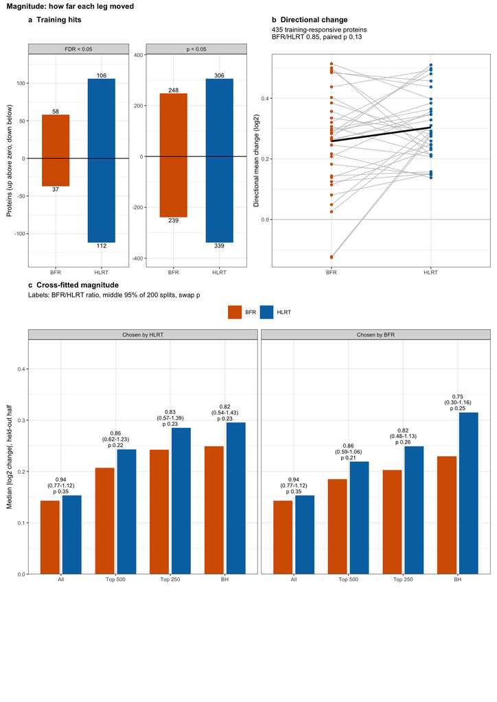

```r
count_plot <- counts |>
  pivot_longer(c(up, down), names_to = "direction", values_to = "proteins") |>
  mutate(proteins = if_else(direction == "down", -proteins, proteins)) |>
  ggplot(aes(arm, proteins, fill = arm)) +
  geom_col(width = 0.6, show.legend = FALSE) +
  geom_hline(yintercept = 0) +
  geom_text(aes(label = abs(proteins), vjust = if_else(proteins > 0, -0.3, 1.2)), size = 2.5) +
  facet_wrap(~level, scales = "free_y") +
  scale_y_continuous(expand = expansion(0.15)) +
  scale_fill_manual(values = arm_colours) +
  labs(x = NULL, y = "Proteins (up above zero, down below)", title = "a  Training hits")
bars <- magnitude |>
  mutate(
    set = factor(set, c("All", "Top 500", "Top 250", "BH")),
    selected_on = factor(paste("Chosen by", selected_on), c("Chosen by HLRT", "Chosen by BFR")),
    label = sprintf("%.2f\n(%.2f-%.2f)\np %.2f", ratio, split_low, split_high, swap_p)
  )
magnitude_plot <- bars |>
  pivot_longer(c(bfr, hlrt), names_to = "arm", values_to = "median_change") |>
  mutate(arm = toupper(arm)) |>
  ggplot(aes(set, median_change, fill = arm)) +
  geom_col(position = position_dodge(0.8), width = 0.7) +
  geom_text(data = bars, aes(set, pmax(bfr, hlrt), label = label), inherit.aes = FALSE,
    vjust = -0.15, size = 2.3, lineheight = 0.9) +
  facet_wrap(~selected_on) +
  scale_fill_manual(values = arm_colours) +
  scale_y_continuous(expand = expansion(c(0, 0.45))) +
  labs(x = NULL, y = "Median |log2 change|, held-out half", fill = NULL,
    title = "c  Cross-fitted magnitude",
    subtitle = "Labels: BFR/HLRT ratio, middle 95% of 200 splits, swap p") +
  theme(legend.position = "top")
score_plot <- directional_pairs |>
  pivot_longer(c(BFR, HLRT), names_to = "arm", values_to = "score") |>
  ggplot(aes(arm, score, group = participant)) +
  geom_hline(yintercept = 0, colour = "grey80") +
  geom_line(colour = "grey75", linewidth = 0.3) +
  geom_point(aes(colour = arm), size = 1.2, show.legend = FALSE) +
  stat_summary(aes(group = 1), fun = mean, geom = "line", linewidth = 1) +
  scale_colour_manual(values = arm_colours) +
  labs(x = NULL, y = "Directional mean change (log2)", title = "b  Directional change",
    subtitle = sprintf("%d training-responsive proteins\nBFR/HLRT %.2f, paired p %.2f",
      directional_test$proteins, directional_test$ratio, directional_test$p))
page_magnitude <- (count_plot | score_plot) / magnitude_plot / plot_spacer() +
  plot_layout(heights = c(1, 1.1, 0.5)) +
  plot_annotation(title = "Magnitude: how far each leg moved")
page_magnitude
```

## Direction

Whether the legs moved the same proteins the same way, and what each quadrant holds. The Deming slope is descriptive: most points are HLRT hits chosen for a large HLRT change, so it is biased low.

```r
bh_in <- function(bfr_fdr, hlrt_fdr) {
  case_when(bfr_fdr < 0.05 & hlrt_fdr < 0.05 ~ "Both", bfr_fdr < 0.05 ~ "BFR",
    hlrt_fdr < 0.05 ~ "HLRT", .default = "neither")
}
direction_hits <- tibble(
  protein = dep$protein, gene = dep$Genes,
  bfr_logfc = dep_stat(ct_bfr, "logFC"), bfr_fdr = dep_stat(ct_bfr, "adj.P.Val"),
  hlrt_logfc = dep_stat(ct_hlrt, "logFC"), hlrt_fdr = dep_stat(ct_hlrt, "adj.P.Val")
) |>
  filter(bfr_fdr < 0.05 | hlrt_fdr < 0.05) |>
  mutate(
    hit = bh_in(bfr_fdr, hlrt_fdr),
    quadrant = paste0(if_else(hlrt_logfc > 0, "HLRT up", "HLRT down"), ", ",
      if_else(bfr_logfc > 0, "BFR up", "BFR down"))
  )
concordance <- mean(sign(direction_hits$bfr_logfc) == sign(direction_hits$hlrt_logfc))
deming_slope <- with(direction_hits, {
  s <- cov(cbind(hlrt_logfc, bfr_logfc))
  (s[2, 2] - s[1, 1] + sqrt((s[2, 2] - s[1, 1])^2 + 4 * s[1, 2]^2)) / (2 * s[1, 2])
})
count(direction_hits, hit)
```

```
# A tibble: 3 × 2
  hit       n
  <chr> <int>
1 BFR      44
2 Both     51
3 HLRT    167
```

```r
count(direction_hits, quadrant)
```

```
# A tibble: 4 × 2
  quadrant                n
  <chr>               <int>
1 HLRT down, BFR down   121
2 HLRT down, BFR up       8
3 HLRT up, BFR down       8
4 HLRT up, BFR up       125
```

```r
c(concordance = concordance, deming_slope = deming_slope)
```

```
 concordance deming_slope
   0.9389313    0.5752055
```

```r
universe <- unique(dep$Genes)
ora_sets <- gene_sets[sub("\\|.*", "", names(gene_sets)) %in% set_databases]
quadrant_sets <- direction_hits |>
  summarise(members = list(unique(gene)), proteins = n(), .by = quadrant) |>
  mutate(result = map(members, function(g) {
    fgsea::fora(ora_sets, g, universe = universe, minSize = 10, maxSize = 500) |>
      as_tibble() |>
      slice_min(pval, n = 10, with_ties = FALSE) |>
      transmute(database = sub("\\|.*", "", pathway), pathway = sub("^[^|]+\\|", "", pathway),
        size, overlap, p = pval, fdr = padj)
  })) |>
  select(quadrant, proteins, result) |>
  unnest(result)
quadrant_sets |>
  slice_min(p, n = 3, by = quadrant) |>
  select(quadrant, proteins, pathway, overlap, fdr)
```

```
# A tibble: 12 × 5
   quadrant            proteins pathway                          overlap     fdr
   <chr>                  <int> <chr>                              <int>   <dbl>
 1 HLRT up, BFR up          125 REACTOME_MITOCHONDRIAL_PROTEIN_…      20 3.34e-8
 2 HLRT up, BFR up          125 REACTOME_CITRIC_ACID_CYCLE_TCA_…      12 1.04e-7
 3 HLRT up, BFR up          125 HALLMARK_OXIDATIVE_PHOSPHORYLAT…      27 1.04e-7
 4 HLRT down, BFR down      121 HALLMARK_KRAS_SIGNALING_DN             5 2.05e-1
 5 HLRT down, BFR down      121 MUSCLE_SYSTEM_PROCESS                 19 2.07e-1
 6 HLRT down, BFR down      121 REACTOME_FORMATION_OF_THE_DYSTR…       4 8.37e-1
 7 HLRT down, BFR up          8 REACTOME_GLYCEROPHOSPHOLIPID_BI…       2 7.03e-1
 8 HLRT down, BFR up          8 REACTOME_PHOSPHOLIPID_METABOLISM       2 7.03e-1
 9 HLRT down, BFR up          8 REACTOME_ABC_FAMILY_PROTEINS_ME…       2 7.03e-1
10 HLRT up, BFR down          8 HALLMARK_APICAL_JUNCTION               2 1   e+0
11 HLRT up, BFR down          8 HALLMARK_EPITHELIAL_MESENCHYMAL…       2 1   e+0
12 HLRT up, BFR down          8 REACTOME_DISEASES_OF_METABOLISM        2 1   e+0
```

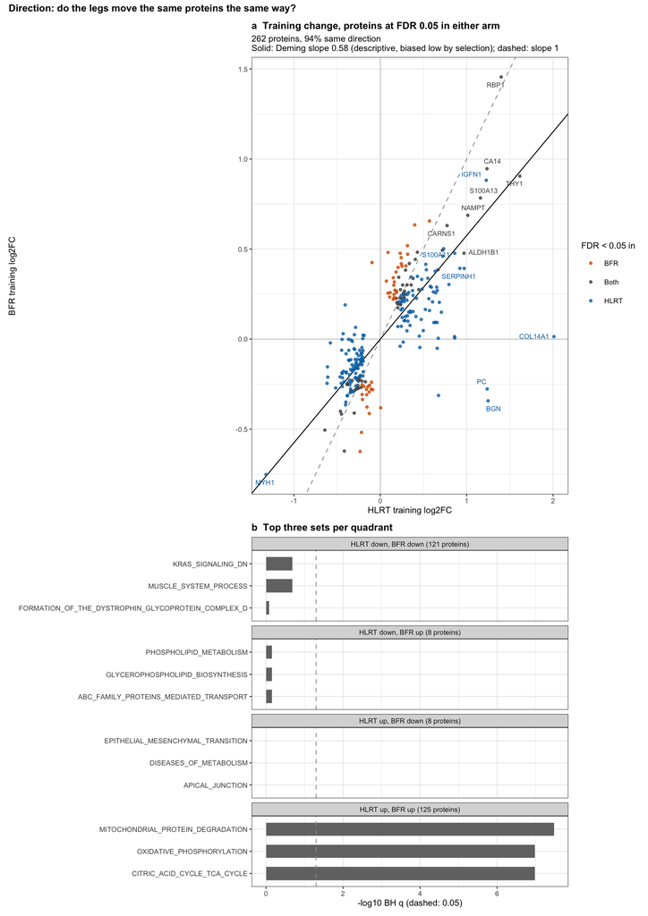

```r
direction_plot <- ggplot(direction_hits, aes(hlrt_logfc, bfr_logfc, colour = hit)) +
  origin_lines +
  geom_abline(slope = deming_slope, colour = "black", linewidth = 0.4) +
  geom_point(size = 1, alpha = 0.8) +
  geom_text_repel(data = slice_max(direction_hits, abs(hlrt_logfc) + abs(bfr_logfc), n = 14),
    aes(label = gene), size = 2.2, show.legend = FALSE, max.overlaps = 30) +
  scale_colour_manual(values = arm_colours) +
  labs(x = "HLRT training log2FC", y = "BFR training log2FC", colour = "FDR < 0.05 in",
    title = "a  Training change, proteins at FDR 0.05 in either arm",
    subtitle = sprintf(paste0("%d proteins, %.0f%% same direction\nSolid: Deming slope %.2f ",
      "(descriptive, biased low by selection); dashed: slope 1"),
      nrow(direction_hits), 100 * concordance, deming_slope))
ora_plot <- quadrant_sets |>
  slice_min(p, n = 3, by = quadrant, with_ties = FALSE) |>
  mutate(
    pathway = substr(sub("^(HALLMARK|REACTOME)_", "", pathway), 1, 50),
    panel = paste0(quadrant, " (", proteins, " proteins)")
  ) |>
  ggplot(aes(-log10(fdr), reorder(pathway, -log10(fdr)))) +
  geom_col(fill = "grey45", width = 0.6) +
  geom_vline(xintercept = -log10(0.05), linetype = "dashed", colour = "grey60") +
  facet_wrap(~panel, scales = "free_y", ncol = 1) +
  labs(x = "-log10 BH q (dashed: 0.05)", y = NULL, title = "b  Top three sets per quadrant")
page_direction <- direction_plot / ora_plot + plot_layout(heights = c(1.3, 1)) +
  plot_annotation(title = "Direction: do the legs move the same proteins the same way?")
page_direction
```

## Coherence

Whether rankings, sets and modules agree between the arms. The rho and r are descriptive, because sets overlap and modules share proteins; fry asks whether HLRT’s hits move together in BFR.

```r
signed_score <- function(ct) -log10(dep_stat(ct, "P.Value")) * sign(dep_stat(ct, "logFC"))
unique_gene <- !duplicated(dep$Genes)
arm_of <- set_names(c("bfr", "hlrt"), c(ct_bfr, ct_hlrt))
rrho <- RRHO2::RRHO2_initialize(
  data.frame(dep$Genes, signed_score(ct_hlrt))[unique_gene, ],
  data.frame(dep$Genes, signed_score(ct_bfr))[unique_gene, ],
  labels = c("HLRT training", "BFR training"), log10.ind = TRUE
)
nes <- set_tests |>
  filter(method == "fgsea", contrast %in% c(ct_bfr, ct_hlrt), database %in% set_databases) |>
  transmute(arm = arm_of[contrast], set_id, nes = NES, fdr = padj) |>
  pivot_wider(names_from = arm, values_from = c(nes, fdr)) |>
  drop_na(nes_bfr, nes_hlrt) |>
  mutate(sig = bh_in(fdr_bfr, fdr_hlrt))
nes_rho <- cor(nes$nes_hlrt, nes$nes_bfr, method = "spearman")
modules <- read_excel(module_file, "eigengene_tests") |>
  filter(contrast %in% c(ct_bfr, ct_hlrt)) |>
  transmute(arm = arm_of[contrast], module, change = estimate, fdr) |>
  pivot_wider(names_from = arm, values_from = c(change, fdr)) |>
  left_join(
    read_excel(module_file, "modules") |> filter(network == "main") |>
      select(module, proteins, hub),
    by = "module"
  )
module_r <- cor(modules$change_hlrt, modules$change_bfr)
hlrt_sets <- list(
  HLRT_up = which(dep_stat(ct_hlrt, "adj.P.Val") < 0.05 & dep_stat(ct_hlrt, "logFC") > 0),
  HLRT_down = which(dep_stat(ct_hlrt, "adj.P.Val") < 0.05 & dep_stat(ct_hlrt, "logFC") < 0)
)
fry_bfr <- fry(proteins, hlrt_sets, d$design, d$contrasts[, ct_bfr], robust = TRUE,
  sort = "none")
coherence <- bind_rows(
  tibble(statistic = "fgsea NES, BFR vs HLRT training, Spearman rho", n = nrow(nes),
    estimate = nes_rho),
  tibble(statistic = "main-network eigengene change, BFR vs HLRT training, Pearson r",
    n = nrow(modules), estimate = module_r),
  tibble(statistic = paste("fry in BFR training,", rownames(fry_bfr), "FDR set"),
    n = fry_bfr$NGenes, direction = fry_bfr$Direction, p = fry_bfr$PValue)
)
coherence
```

```
# A tibble: 4 × 5
  statistic                                       n estimate direction         p
  <chr>                                       <int>    <dbl> <chr>         <dbl>
1 fgsea NES, BFR vs HLRT training, Spearman …   530    0.851 <NA>      NA
2 main-network eigengene change, BFR vs HLRT…     7    0.922 <NA>      NA
3 fry in BFR training, HLRT_up FDR set          106   NA     Up         2.12e-11
4 fry in BFR training, HLRT_down FDR set        112   NA     Down       6.65e-14
```

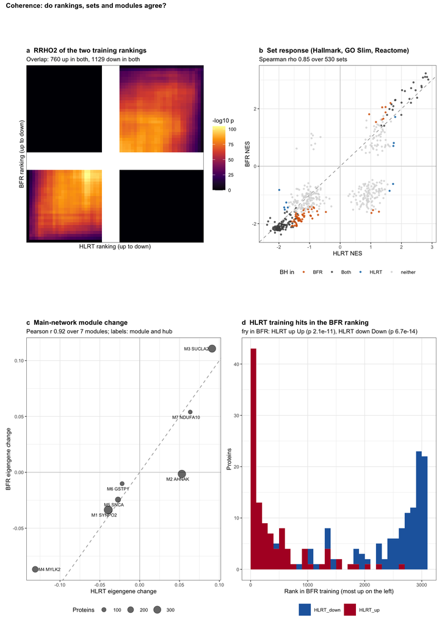

```r
rrho_cells <- as_tibble(rrho$hypermat, .name_repair = function(x) as.character(seq_along(x))) |>
  mutate(hlrt_step = row_number()) |>
  pivot_longer(-hlrt_step, names_to = "bfr_step", values_to = "log_p",
    names_transform = as.integer)
rrho_plot <- ggplot(rrho_cells, aes(hlrt_step, bfr_step, fill = log_p)) +
  geom_raster() +
  scale_fill_viridis_c(option = "inferno", na.value = "white") +
  coord_equal(expand = FALSE) +
  labs(x = "HLRT ranking (up to down)", y = "BFR ranking (up to down)", fill = "-log10 p",
    title = "a  RRHO2 of the two training rankings",
    subtitle = sprintf("Overlap: %d up in both, %d down in both",
      length(rrho$genelist_uu$gene_list_overlap_uu),
      length(rrho$genelist_dd$gene_list_overlap_dd))) +
  theme(axis.text = element_blank(), axis.ticks = element_blank())
nes_plot <- ggplot(nes, aes(nes_hlrt, nes_bfr, colour = sig)) +
  origin_lines +
  geom_point(size = 0.8, alpha = 0.8) +
  scale_colour_manual(values = c(arm_colours, neither = "grey85")) +
  labs(x = "HLRT NES", y = "BFR NES", colour = "BH in",
    title = "b  Set response (Hallmark, GO Slim, Reactome)",
    subtitle = sprintf("Spearman rho %.2f over %d sets", nes_rho, nrow(nes))) +
  theme(legend.position = "bottom")
module_plot <- ggplot(modules, aes(change_hlrt, change_bfr)) +
  origin_lines +
  geom_point(aes(size = proteins), alpha = 0.6) +
  geom_text_repel(aes(label = paste(module, hub)), size = 2.1, max.overlaps = 30) +
  scale_size_area(max_size = 5) +
  labs(x = "HLRT eigengene change", y = "BFR eigengene change", size = "Proteins",
    title = "c  Main-network module change",
    subtitle = sprintf("Pearson r %.2f over %d modules; labels: module and hub", module_r,
      nrow(modules))) +
  theme(legend.position = "bottom")
bfr_rank <- rank(-fit$t[, ct_bfr])
barcode <- imap(hlrt_sets, function(rows, set) tibble(set = set, bfr_rank = bfr_rank[rows])) |>
  list_rbind()
barcode_plot <- ggplot(barcode, aes(bfr_rank, fill = set)) +
  geom_histogram(binwidth = 100, boundary = 0) +
  scale_fill_manual(values = c(HLRT_up = "#B2182B", HLRT_down = "#2166AC")) +
  labs(x = "Rank in BFR training (most up on the left)", y = "Proteins", fill = NULL,
    title = "d  HLRT training hits in the BFR ranking",
    subtitle = sprintf("fry in BFR: HLRT up %s (p %.1e), HLRT down %s (p %.1e)",
      fry_bfr["HLRT_up", "Direction"], fry_bfr["HLRT_up", "PValue"],
      fry_bfr["HLRT_down", "Direction"], fry_bfr["HLRT_down", "PValue"])) +
  theme(legend.position = "bottom")
page_coherence <- (rrho_plot | nes_plot) / (module_plot | barcode_plot) +
  plot_annotation(title = "Coherence: do rankings, sets and modules agree?")
page_coherence
```

## Classification

The sPLS-DA AUCs of `07_Multivariate/02_splsda` set the between-arm comparisons against training on one page. Panel sizes were tuned on the same data, so they lean optimistic.

```r
comparison_names <- c(
  training_bfr = "BFR: T1 vs T2", training_hlrt = "HLRT: T1 vs T2",
  arms_pre = "BFR vs HLRT, before", arms_post = "BFR vs HLRT, after",
  arms_change = "BFR vs HLRT, change"
)
classification <- read_excel(splsda_file, "models") |>
  filter(component == 1) |>
  transmute(comparison, label = comparison_names[comparison], participants = n_participants,
    panel_size = keep_x, ber = ber_max, auc, auc_sd)
classification
```

```
# A tibble: 5 × 7
  comparison    label              participants panel_size     ber   auc  auc_sd
  <chr>         <chr>                     <dbl>      <dbl>   <dbl> <dbl>   <dbl>
1 training_bfr  BFR: T1 vs T2                32       1000 0.176   0.879 0.0199
2 training_hlrt HLRT: T1 vs T2               33         20 0.00606 1.000 0.00101
3 arms_pre      BFR vs HLRT, befo…           33          5 0.394   0.669 0.0761
4 arms_post     BFR vs HLRT, after           32        500 0.444   0.600 0.0532
5 arms_change   BFR vs HLRT, chan…           32         50 0.459   0.575 0.0648
```

## BFR against HLRT leads

No interaction passes BH, so proteins at nominal p < 0.05 are leads. fgsea treats correlated proteins as independent and fry passes no interaction set, so the fgsea sets are leads too.

```r
change_panel <- read_excel(splsda_file, "panels") |>
  filter(comparison == "arms_change", component == 1)
volcano_data <- tibble(
  protein = dep$protein, gene = dep$Genes,
  interaction_logfc = dep_stat(ct_inter, "logFC"), interaction_p = dep_stat(ct_inter, "P.Value"),
  interaction_fdr = dep_stat(ct_inter, "adj.P.Val"),
  bfr_logfc = dep_stat(ct_bfr, "logFC"), bfr_p = dep_stat(ct_bfr, "P.Value"),
  hlrt_logfc = dep_stat(ct_hlrt, "logFC"), hlrt_p = dep_stat(ct_hlrt, "P.Value")
) |>
  mutate(in_change_panel = protein %in% change_panel$protein, lead = interaction_p < 0.05)
leads <- volcano_data |>
  filter(lead) |>
  select(-lead) |>
  arrange(interaction_p)
inter_sets <- set_tests |>
  filter(method == "fgsea", contrast == ct_inter, database %in% set_databases) |>
  slice_min(p, n = 12, with_ties = FALSE) |>
  mutate(label = sprintf("%s (q %.2g)", substr(sub("^(HALLMARK|REACTOME)_", "", pathway), 1, 45),
    padj))
c(leads = nrow(leads), larger_bfr = sum(leads$interaction_logfc > 0),
  larger_hlrt = sum(leads$interaction_logfc < 0),
  panel_in_leads = sum(leads$in_change_panel), panel = nrow(change_panel))
```

```
         leads     larger_bfr    larger_hlrt panel_in_leads          panel
           126             54             72             45             50
```

```r
select(inter_sets, database, label, NES, p, padj)
```

```
# A tibble: 12 × 5
   database label                                            NES       p    padj
   <chr>    <chr>                                          <dbl>   <dbl>   <dbl>
 1 GO_Slim  vesicle-mediated transport (q 0.00083)         -1.67 8.31e-7 8.33e-4
 2 GO_Slim  cell motility (q 0.00083)                      -1.76 8.37e-7 8.33e-4
 3 GO_Slim  cell adhesion (q 0.0011)                       -1.80 1.67e-6 1.11e-3
 4 GO_Slim  cytoskeleton organization (q 0.0027)           -1.64 5.50e-6 2.74e-3
 5 Hallmark EPITHELIAL_MESENCHYMAL_TRANSITION (q 0.005)    -2.05 1.30e-5 4.96e-3
 6 Hallmark APICAL_JUNCTION (q 0.005)                      -2.06 1.74e-5 4.96e-3
 7 GO_Slim  wound healing (q 0.011)                        -1.89 5.84e-5 1.06e-2
 8 Reactome RHO_GTPASE_EFFECTORS (q 0.015)                 -1.86 9.86e-5 1.51e-2
 9 GO_Slim  programmed cell death (q 0.033)                -1.48 3.58e-4 3.34e-2
10 Reactome EXTRACELLULAR_MATRIX_ORGANIZATION (q 0.049)    -1.76 9.02e-4 4.85e-2
11 Hallmark APOPTOSIS (q 0.053)                            -1.81 1.06e-3 5.31e-2
12 Reactome PLATELET_ACTIVATION_SIGNALING_AND_AGGREGATION… -1.73 1.07e-3 5.31e-2
```

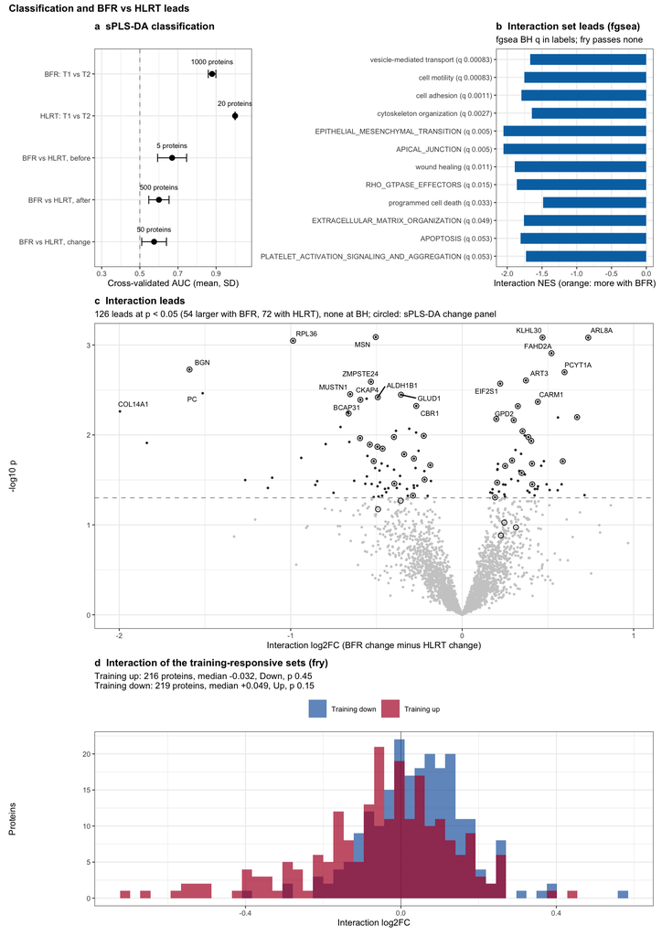

```r
class_plot <- classification |>
  mutate(label = factor(label, rev(comparison_names))) |>
  ggplot(aes(auc, label)) +
  geom_vline(xintercept = 0.5, linetype = "dashed", colour = "grey60") +
  geom_errorbar(aes(xmin = auc - auc_sd, xmax = auc + auc_sd), width = 0.2,
    orientation = "y") +
  geom_point(size = 2) +
  geom_text(aes(label = paste(panel_size, "proteins")), nudge_y = 0.3, size = 2.2) +
  scale_x_continuous(limits = c(0.3, 1.05)) +
  labs(x = "Cross-validated AUC (mean, SD)", y = NULL, title = "a  sPLS-DA classification")
set_plot <- ggplot(inter_sets, aes(NES, reorder(label, -p), fill = NES > 0)) +
  geom_col(width = 0.6, show.legend = FALSE) +
  scale_fill_manual(values = c(`TRUE` = "#D55E00", `FALSE` = "#0072B2")) +
  labs(x = "Interaction NES (orange: more with BFR)", y = NULL,
    title = "b  Interaction set leads (fgsea)", subtitle = "fgsea BH q in labels; fry passes none")
volcano <- ggplot(volcano_data, aes(interaction_logfc, -log10(interaction_p))) +
  geom_point(aes(colour = lead), size = 0.6, show.legend = FALSE) +
  geom_point(data = filter(volcano_data, in_change_panel), shape = 21, size = 1.8,
    stroke = 0.5, colour = "black") +
  geom_hline(yintercept = -log10(0.05), linetype = "dashed", colour = "grey60") +
  geom_text_repel(data = slice_min(leads, interaction_p, n = 20), aes(label = gene), size = 2.2,
    max.overlaps = 40) +
  scale_colour_manual(values = c(`TRUE` = "grey20", `FALSE` = "grey80")) +
  labs(x = "Interaction log2FC (BFR change minus HLRT change)", y = "-log10 p",
    title = "c  Interaction leads",
    subtitle = sprintf(paste0("%d leads at p < 0.05 (%d larger with BFR, %d with HLRT), none at ",
      "BH; circled: sPLS-DA change panel"), nrow(leads), sum(leads$interaction_logfc > 0),
      sum(leads$interaction_logfc < 0)))
fry_data <- imap(training_set, function(rows, set) {
  tibble(set = paste("Training", set), interaction_logfc = interaction_change[rows])
}) |>
  list_rbind()
fry_label <- with(fry_interaction, sprintf("%s: %d proteins, median %+.3f, %s, p %.2f",
  paste("Training", set), NGenes, median_interaction, Direction, PValue))
fry_plot <- ggplot(fry_data, aes(interaction_logfc, fill = set)) +
  geom_vline(xintercept = 0, colour = "grey60") +
  geom_histogram(bins = 50, alpha = 0.7, position = "identity") +
  scale_fill_manual(values = c(`Training up` = "#B2182B", `Training down` = "#2166AC")) +
  labs(x = "Interaction log2FC", y = "Proteins", fill = NULL,
    title = "d  Interaction of the training-responsive sets (fry)",
    subtitle = paste(fry_label, collapse = "\n")) +
  theme(legend.position = "top")
page_leads <- (class_plot | set_plot) / volcano / fry_plot +
  plot_layout(heights = c(1, 1.4, 0.8)) +
  plot_annotation(title = "Classification and BFR vs HLRT leads")
page_leads
```

## Response against growth

Whether a leg that moved further also grew more. Centring a participant’s two legs makes them mirror images, so the pooled within-participant p comes from 5,000 swaps of the response between a participant’s legs, not from `cor.test()`.

```r
per_sample <- function(sheet_file, sheet, value) {
  read_excel(sheet_file, sheet) |>
    select(participant, leg, timepoint, value = all_of(value)) |>
    pivot_wider(names_from = timepoint, values_from = value) |>
    transmute(participant, leg, change = T2 - T1)
}
mpe_change <- per_sample(
  here("05_Mitochondria", "02_test_mito", "c_data", "02_test_mito.xlsx"), "mpe", "mpe"
)
slow_change <- per_sample(
  here("06_Composition", "02_fibre_type", "c_data", "02_fibre_type.xlsx"), "slow_fraction",
  "slow"
)
legs <- leg_samples |>
  select(participant, leg, treatment) |>
  mutate(directional_change = directional(leg_change)) |>
  left_join(rename(mpe_change, mpe_change = change), by = c("participant", "leg")) |>
  left_join(rename(slow_change, slow_change = change), by = c("participant", "leg")) |>
  left_join(
    transmute(phenotype, participant, leg,
      vl_csa = vl_csa_post_cm2 - vl_csa_pre_cm2, rf_csa = rf_csa_post_cm2 - rf_csa_pre_cm2,
      vl_echo = vl_echo_post_au - vl_echo_pre_au, rf_echo = rf_echo_post_au - rf_echo_pre_au),
    by = c("participant", "leg"), relationship = "one-to-one"
  ) |>
  mutate(both_legs = participant %in% complete_legs$participant) |>
  arrange(participant, treatment)
stopifnot(!anyNA(select(legs, -both_legs)))
count(legs, treatment)
```

```
# A tibble: 2 × 2
  treatment     n
  <chr>     <int>
1 BFR          32
2 HLRT         33
```

```r
responses <- c(directional_change = "Directional change", mpe_change = "MPE change",
  slow_change = "Slow-fraction change")
outcomes <- c(vl_csa = "VL CSA change (cm²)", rf_csa = "RF CSA change (cm²)",
  vl_echo = "VL echo change (a.u.)", rf_echo = "RF echo change (a.u.)")
within_rho <- function(x, y, person, flips = 5000) {
  x <- x - ave(x, person)
  y <- y - ave(y, person)
  observed <- cor(x, y, method = "spearman")
  people <- unique(person)
  null <- replicate(flips, {
    sign_flip <- sample(c(-1, 1), length(people), replace = TRUE)[match(person, people)]
    cor(x * sign_flip, y, method = "spearman")
  })
  tibble(rho = observed, n = length(x),
    p = (1 + sum(abs(null) >= abs(observed))) / (1 + flips))
}
growth <- expand_grid(response = names(responses), outcome = names(outcomes)) |>
  mutate(result = map2(response, outcome, function(r, o) {
    by_arm <- map(c("BFR", "HLRT"), function(arm) {
      arm_legs <- filter(legs, treatment == arm)
      test <- cor.test(arm_legs[[r]], arm_legs[[o]], method = "spearman", exact = FALSE)
      tibble(analysis = arm, rho = unname(test$estimate), n = nrow(arm_legs), p = test$p.value)
    })
    paired <- filter(legs, both_legs)
    bind_rows(by_arm, mutate(within_rho(paired[[r]], paired[[o]], paired$participant),
      analysis = "within participant"))
  })) |>
  unnest(result) |>
  select(response, outcome, analysis, rho, n, p)
growth |>
  slice_max(abs(rho), n = 6) |>
  mutate(across(c(rho, p), function(x) signif(x, 2)))
```

```
# A tibble: 6 × 6
  response           outcome analysis             rho     n      p
  <chr>              <chr>   <chr>              <dbl> <int>  <dbl>
1 directional_change vl_echo within participant -0.51    64 0.0014
2 directional_change vl_csa  HLRT                0.34    33 0.051
3 slow_change        rf_echo BFR                 0.32    32 0.078
4 slow_change        vl_echo BFR                 0.26    32 0.15
5 mpe_change         vl_echo HLRT                0.23    33 0.19
6 directional_change rf_csa  HLRT                0.22    33 0.21
```

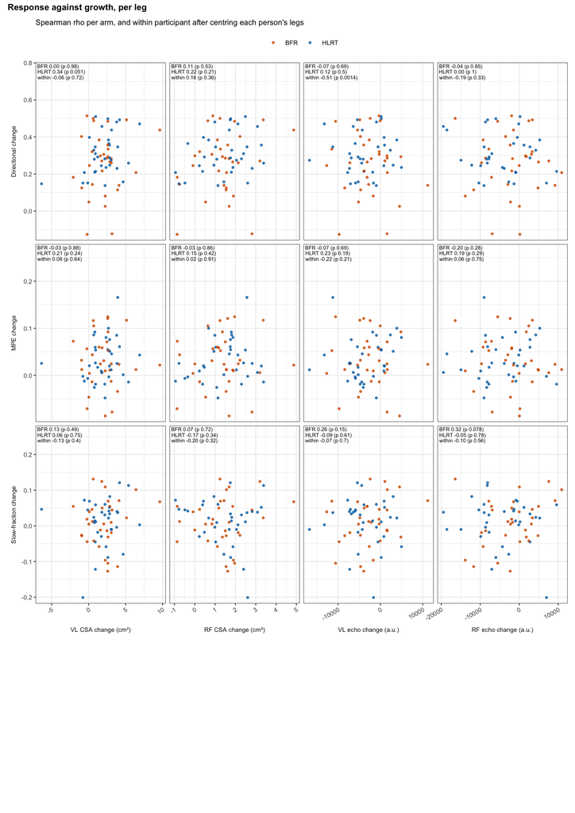

```r
growth_points <- legs |>
  pivot_longer(names(responses), names_to = "response", values_to = "response_value") |>
  pivot_longer(names(outcomes), names_to = "outcome", values_to = "outcome_value") |>
  mutate(response = factor(responses[response], responses),
    outcome = factor(outcomes[outcome], outcomes))
growth_labels <- growth |>
  mutate(text = sprintf("%s %.2f (p %.2g)", sub(" participant", "", analysis), rho, p)) |>
  summarise(text = paste(text, collapse = "\n"), .by = c(response, outcome)) |>
  mutate(response = factor(responses[response], responses),
    outcome = factor(outcomes[outcome], outcomes))
growth_plot <- ggplot(growth_points, aes(outcome_value, response_value, colour = treatment)) +
  geom_point(size = 0.9, alpha = 0.8) +
  geom_text(data = growth_labels, aes(x = -Inf, y = Inf, label = text), inherit.aes = FALSE,
    hjust = -0.04, vjust = 1.1, size = 1.9, lineheight = 0.9) +
  facet_grid(response ~ outcome, scales = "free", switch = "both") +
  scale_y_continuous(expand = expansion(c(0.05, 0.45))) +
  scale_colour_manual(values = arm_colours[c("BFR", "HLRT")]) +
  labs(x = NULL, y = NULL, colour = NULL,
    subtitle = "Spearman rho per arm, and within participant after centring each person's legs") +
  theme(legend.position = "top", strip.placement = "outside",
    strip.background = element_blank(), axis.text.x = element_text(angle = 30, hjust = 1))
page_growth <- growth_plot / plot_spacer() + plot_layout(heights = c(1, 0.3)) +
  plot_annotation(title = "Response against growth, per leg")
page_growth
```

```r
pdf(file.path(stage, "b_reports", "01_plasticity.pdf"), width = 8.27, height = 11.69)
print(page_magnitude)
print(page_direction)
print(page_coherence)
print(page_leads)
print(page_growth)
invisible(dev.off())
```

## Save results

```r
tests <- bind_rows(
  directional_test,
  transmute(fry_interaction, test = paste("fry interaction, training", set), proteins = NGenes,
    median_training, median_interaction, direction = Direction, p = PValue)
)
write_xlsx(
  list(
    counts = counts,
    magnitude = magnitude |>
      mutate(selected_on = if_else(set == "All", "none", selected_on)) |>
      distinct(selected_on, set, .keep_all = TRUE),
    legs = legs,
    direction = direction_hits,
    quadrant_sets = quadrant_sets,
    coherence = coherence,
    leads = leads,
    tests = tests,
    growth = growth
  ),
  file.path(stage, "c_data", "01_plasticity.xlsx")
)
```